# Cross Validation II

Methods to Minimize Error

Alexander Demos

2025-04-21

# Today’s Goal

A deeper dive in the setting the parameters that we need for Cross Validation.

## Simulation

Create a set of data with 4 completely uncorrelated predictors each at $r = .2$ with $Y$, N = 200. This will give an $R^2 = .16$. This simulation has no noise and if we run the model will all the data we would get these exact values.

```r
library(caret)
library(MASS) #create data

N=200
X1Y =.2; X2Y =.2; X3Y =.2; X4Y =.2
X1X2= 0; X1X3= 0; X1X4= 0
X2X3= 0; X2X4= 0
X3X4= 0;

Means<- c(5,0,0,0,0) #set the means of X and Y variables
CovMatrix        <- matrix(c(1, X1Y,  X2Y, X3Y, X4Y,
                            X1Y,1   ,X1X2,X1X3,X1X4,
                            X2Y,X1X2,1,   X2X3,X2X4,
                            X3Y,X1X3,X2X3,1,   X3X4,
                            X4Y,X1X4,X2X4,X3X4   ,1),5,5) # creates the covariate matrix
set.seed(42)
CorrDataT<-mvrnorm(n=N, mu=Means,Sigma=CovMatrix, empirical=TRUE)
#Convert them to a "Data.Frame" & add our labels to the vectors we created
AcurracyExample<-as.data.frame(CorrDataT)
colnames(AcurracyExample) <- c("DV","IV1","IV2","IV3","IV4")
```

# K-Fold CV

Here we set the K number (5,10,20,40) and compare the results. We will also `preProcess` the data on the fly. We can `center`, `scale` (defaults), remove near zero predictors (`nzv`). It says it can remove highly correlated predictors `corr`, but I cannot get it work. It has a set of transforms as well, `BoxCox`,`expoTrans` and a few others. It says it can condense the predicts on the fly, e.g., `pca`,`ica`. Impute missing values and a few other things. My suggestion is don’t trust without checking to make sure these make sense and are working as stated.

```r
# Define training control
train.control.CV5 <- trainControl(method = "cv",
                              number = 5)
train.control.CV10 <- trainControl(method = "cv",
                              number = 10)
train.control.CV20 <- trainControl(method = "cv",
                              number = 20)
train.control.CV40 <- trainControl(method = "cv",
                              number = 40)
# Train the model

model.CV5 <- train(DV ~., data=AcurracyExample, method = "lm",
               trControl = train.control.CV5,
               preProcess=c("center", "scale","nzv"))
model.CV10 <- train(DV ~., data=AcurracyExample, method = "lm",
               trControl = train.control.CV10,
               preProcess=c("center", "scale","nzv"))
model.CV20 <- train(DV ~., data=AcurracyExample, method = "lm",
               trControl = train.control.CV20,
               preProcess=c("center", "scale","nzv"))
model.CV40 <- train(DV ~., data=AcurracyExample, method = "lm",
               trControl = train.control.CV40,
               preProcess=c("center", "scale","nzv"))
```

5-Fold Results

```r
kable(model.CV5$results, digits=4)
```

| intercept | RMSE | Rsquared | MAE | RMSESD | RsquaredSD | MAESD |
| --- | --- | --- | --- | --- | --- | --- |
| TRUE | 0.9673 | 0.1247 | 0.7774 | 0.0901 | 0.1227 | 0.0894 |

10-Fold Results

```r
kable(model.CV10$results, digits=4)
```

| intercept | RMSE | Rsquared | MAE | RMSESD | RsquaredSD | MAESD |
| --- | --- | --- | --- | --- | --- | --- |
| TRUE | 0.9323 | 0.2211 | 0.7538 | 0.1443 | 0.2174 | 0.1044 |

20-Fold Results

```r
kable(model.CV20$results, digits=4)
```

| intercept | RMSE | Rsquared | MAE | RMSESD | RsquaredSD | MAESD |
| --- | --- | --- | --- | --- | --- | --- |
| TRUE | 0.9315 | 0.259 | 0.7549 | 0.1637 | 0.2281 | 0.1295 |

40-Fold Results

```r
kable(model.CV40$results, digits=4)
```

| intercept | RMSE | Rsquared | MAE | RMSESD | RsquaredSD | MAESD |
| --- | --- | --- | --- | --- | --- | --- |
| TRUE | 0.9023 | 0.3244 | 0.7493 | 0.243 | 0.2916 | 0.1907 |

## $R^2$ on CV

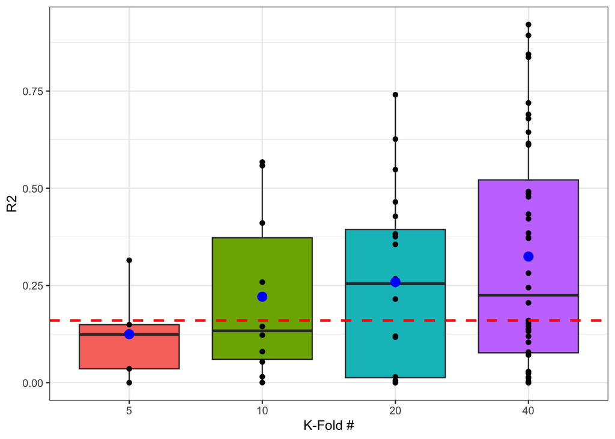

```r
Kfold.Result.Plot<-tibble(CV=c(rep(5, 5),rep(10, 10),rep(20, 20),rep(40, 40)),
                          RMSE = c(model.CV5$resample$RMSE,model.CV10$resample$RMSE,
                                   model.CV20$resample$RMSE,model.CV40$resample$RMSE),
                          R2 = c(model.CV5$resample$Rsquared,model.CV10$resample$Rsquared,
                                 model.CV20$resample$Rsquared,model.CV40$resample$Rsquared))

Kfold.Result.Plot %>%
  ggplot(aes(x = reorder(CV,CV), y=R2, fill=as.factor(CV)))+
  geom_boxplot()+
  geom_point()+
  xlab("K-Fold #")+ylab("R2")+
  geom_hline(yintercept=summary(TrueModel)$r.squared, linetype="dashed",
                color = "red", size=1)+
    stat_summary(fun=mean, geom="point", shape=20, size=5, color="blue", fill="blue") +
  theme_bw()+
  theme(legend.position = "none",
        legend.title = element_blank())
```

So is something is wrong with 40 fold? Why did this break down and give crazy results.

Also, I noticed as well that the package is simply averaging $R^2$, which you technically you should not do. We can improve the accuracy if we covert them to Fisher Z and back again. You can see they give slightly different results.

```r
Table.CT<-Kfold.Result.Plot %>%
  group_by(CV) %>%
  summarise(rawMeanR2=mean(R2),
            CorrectedR2=psych::fisherz2r(mean(psych::fisherz(R2^.5)))^2)
kable(Table.CT)
```

| CV | rawMeanR2 | CorrectedR2 |
| --- | --- | --- |
| 5 | 0.1247309 | 0.0965364 |
| 10 | 0.2210880 | 0.1922666 |
| 20 | 0.2590451 | 0.2253011 |
| 40 | 0.3243704 | 0.3283034 |

## RMSE on CV

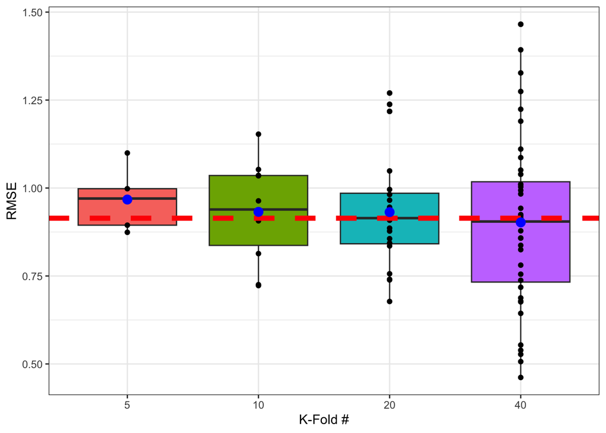

```r
Kfold.Result.Plot %>%
  ggplot(aes(x = reorder(CV,CV), y=RMSE, fill=as.factor(CV)))+
  geom_boxplot()+
  geom_point()+
  xlab("K-Fold #")+ylab("RMSE")+
  geom_hline(yintercept=TRUE.RMSE, linetype="dashed",
                color = "red", size=2)+
    stat_summary(fun=mean, geom="point", shape=20, size=5, color="blue", fill="blue") +
  theme_bw()+
  theme(legend.position = "none",
        legend.title = element_blank())
```

# Repeated K-Fold CV

We will do a 10-fold CV repeatedly (5,10,20,40). We will see how many makes sense in smallish dataset.

```r
set.seed(42)
train.control.CVR5 <- trainControl(method = "repeatedcv",
                              number = 10, repeats = 5)
train.control.CVR10 <- trainControl(method = "repeatedcv",
                              number = 10, repeats = 10)
train.control.CVR20 <- trainControl(method = "repeatedcv",
                              number = 10, repeats = 20)
train.control.CVR40 <- trainControl(method = "repeatedcv",
                              number = 10, repeats = 40)
# Train the model
model.R5 <- train(DV ~., data=AcurracyExample, method = "lm",
               trControl = train.control.CVR5,
               preProcess=c("center", "scale","nzv"))
model.R10 <- train(DV ~., data=AcurracyExample, method = "lm",
               trControl = train.control.CVR10,
               preProcess=c("center", "scale","nzv"))
model.R20 <- train(DV ~., data=AcurracyExample, method = "lm",
               trControl = train.control.CVR20,
               preProcess=c("center", "scale","nzv"))
model.R40 <- train(DV ~., data=AcurracyExample, method = "lm",
               trControl = train.control.CVR40,
               preProcess=c("center", "scale","nzv"))
```

10-Fold Results, Repeated 5 times

```r
kable(model.R5$results, digits=4)
```

| intercept | RMSE | Rsquared | MAE | RMSESD | RsquaredSD | MAESD |
| --- | --- | --- | --- | --- | --- | --- |
| TRUE | 0.9347 | 0.1655 | 0.7558 | 0.1111 | 0.1577 | 0.0885 |

10-Fold Results, Repeated 10 times

```r
kable(model.R10$results, digits=4)
```

| intercept | RMSE | Rsquared | MAE | RMSESD | RsquaredSD | MAESD |
| --- | --- | --- | --- | --- | --- | --- |
| TRUE | 0.9249 | 0.1698 | 0.7501 | 0.1354 | 0.1471 | 0.1124 |

10-Fold Results, Repeated 20 times

```r
kable(model.R20$results, digits=4)
```

| intercept | RMSE | Rsquared | MAE | RMSESD | RsquaredSD | MAESD |
| --- | --- | --- | --- | --- | --- | --- |
| TRUE | 0.9327 | 0.1723 | 0.7545 | 0.1144 | 0.1445 | 0.0879 |

10-Fold Results, Repeated 40 times

```r
kable(model.R40$results, digits=4)
```

| intercept | RMSE | Rsquared | MAE | RMSESD | RsquaredSD | MAESD |
| --- | --- | --- | --- | --- | --- | --- |
| TRUE | 0.9306 | 0.1702 | 0.7539 | 0.1289 | 0.1457 | 0.1034 |

## $R^2$ Repeated K-Fold

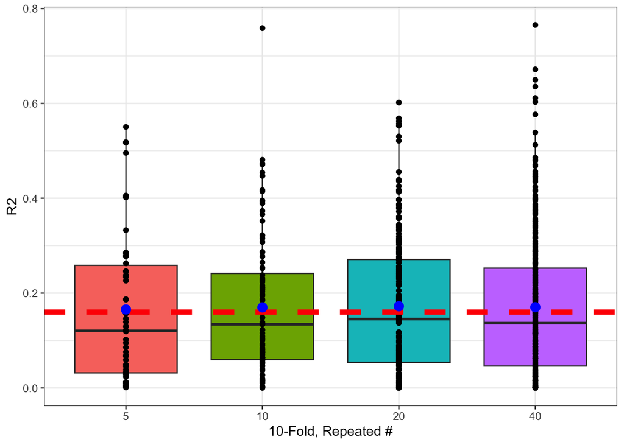

```r
Kfold.Repeated.Result.Plot<-tibble(CV=c(rep(5, 5*10),rep(10, 10*10),rep(20, 20*10),rep(40, 40*10)),
                          RMSE = c(model.R5$resample$RMSE,model.R10$resample$RMSE,
                                   model.R20$resample$RMSE,model.R40$resample$RMSE),
                          R2 = c(model.R5$resample$Rsquared,model.R10$resample$Rsquared,
                                 model.R20$resample$Rsquared,model.R40$resample$Rsquared))

Kfold.Repeated.Result.Plot %>%
  ggplot(aes(x = reorder(CV,CV), y=R2, fill=as.factor(CV)))+
  geom_boxplot()+
  geom_point()+
  xlab("10-Fold, Repeated #")+ylab("R2")+
  geom_hline(yintercept=summary(TrueModel)$r.squared, linetype="dashed",
                color = "red", size=2)+
  stat_summary(fun=mean, geom="point", shape=20, size=5, color="blue", fill="blue") +
  theme_bw()+
  theme(legend.position = "none",
        legend.title = element_blank())
```

## RMSE Repeated K-Fold

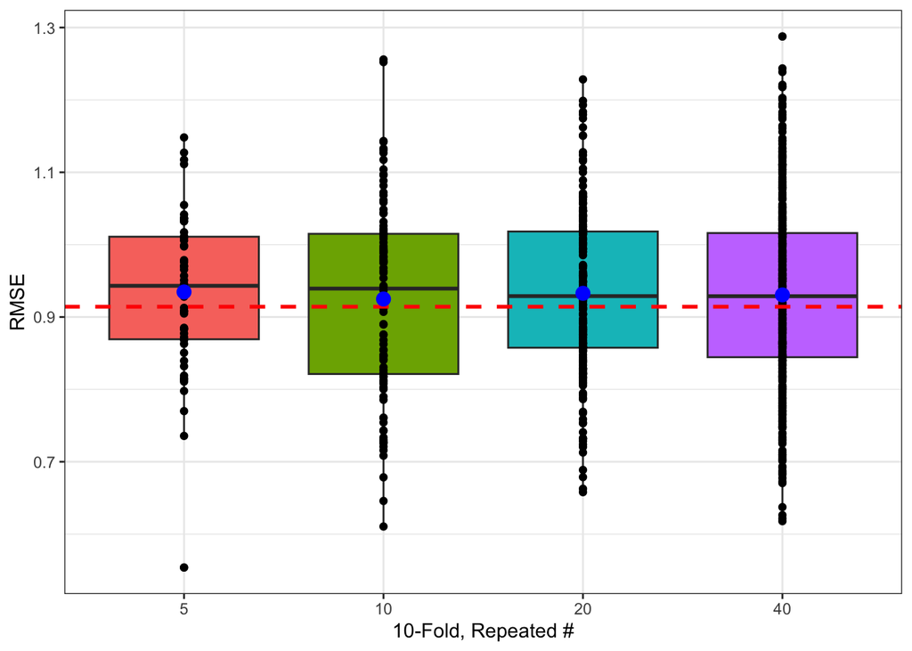

```r
Kfold.Repeated.Result.Plot %>%
  ggplot(aes(x = reorder(CV,CV), y=RMSE, fill=as.factor(CV)))+
  geom_boxplot()+
  geom_point()+
   xlab("10-Fold, Repeated #")+ylab("RMSE")+
  geom_hline(yintercept=TRUE.RMSE, linetype="dashed",
                color = "red", size=1)+
    stat_summary(fun=mean, geom="point", shape=20, size=5, color="blue", fill="blue") +
  theme_bw()+
  theme(legend.position = "none",
        legend.title = element_blank())
```

Lots of lots of repeated, so not make a big difference, but repeated K-Fold CV is probably better than just K-Fold, but picking the right number of folds is the most important.

# LOOCV

```r
set.seed(42)
# Define training control
train.control <- trainControl(method = "LOOCV")
# Train the model
model.LOOCV <- train(DV ~., data=AcurracyExample, method = "lm",
               trControl = train.control,
               preProcess=c("center", "scale","nzv"))
# Summarize the results
model.LOOCV
```

```
## Linear Regression
##
## 200 samples
##   4 predictor
##
## Pre-processing: centered (4), scaled (4)
## Resampling: Leave-One-Out Cross-Validation
## Summary of sample sizes: 199, 199, 199, 199, 199, 199, ...
## Resampling results:
##
##   RMSE       Rsquared   MAE
##   0.9403976  0.1150831  0.7555026
##
## Tuning parameter 'intercept' was held constant at a value of TRUE
```

```r
kable(model.LOOCV$results, digits=4)
```

| intercept | RMSE | Rsquared | MAE |
| --- | --- | --- | --- |
| TRUE | 0.9404 | 0.1151 | 0.7555 |

# Bootstrapping

The bootstrap will not create a training vs test set. Instead it will simply do sampling with replacement.

```r
set.seed(42)
# Define training control
train.control.boot <- trainControl(method = "boot", n=2000)
# Train the model
model.boot <- train(DV ~., data=AcurracyExample, method = "lm",
               trControl = train.control.boot,
               preProcess=c("center", "scale","nzv"))
# Summarize the results
model.boot
```

```
## Linear Regression
##
## 200 samples
##   4 predictor
##
## Pre-processing: centered (4), scaled (4)
## Resampling: Bootstrapped (2000 reps)
## Summary of sample sizes: 200, 200, 200, 200, 200, 200, ...
## Resampling results:
##
##   RMSE       Rsquared   MAE
##   0.9522316  0.1254322  0.7642394
##
## Tuning parameter 'intercept' was held constant at a value of TRUE
```

```r
kable(model.boot$results, digits=4)
```

| intercept | RMSE | Rsquared | MAE | RMSESD | RsquaredSD | MAESD |
| --- | --- | --- | --- | --- | --- | --- |
| TRUE | 0.9522 | 0.1254 | 0.7642 | 0.0654 | 0.0635 | 0.0548 |

Here is a histogram of the $R^2$ values

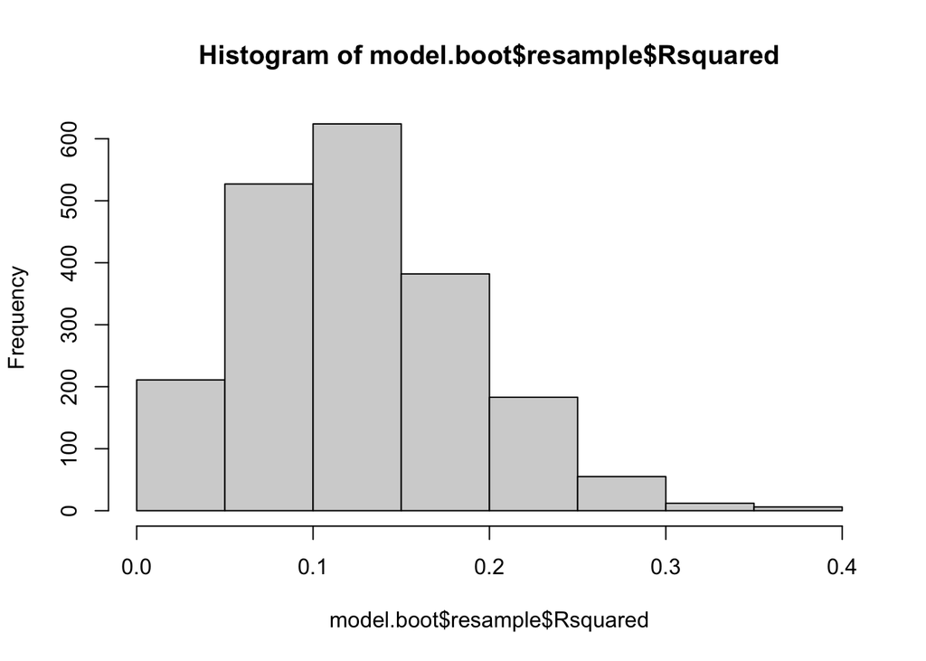

```r
hist(model.boot$resample$Rsquared)
```

```r
quantile(model.boot$resample$Rsquared, c(.05,.95))
```

```
##         5%        95%
## 0.03191818 0.24069141
```

# Conclusion

Which should be pick? Well it depends on our sample size. Here is simulation where use 3 methods (10-Fold, Repeated 10-Fold, and LOOCV) where we go from $N = 50$ to $N = 500$, by $50$. We will do Estimate metric - Actual Metric (from simulation). Postiive will be inflated and negative will mean deflated.

[figure not shown]

Simulation A

[figure not shown]

Simulation B